# HW 03 - Modelling

Mario Pizarro - Salvia (s2974515)

20 November 2026

## Data load and preparation before modelling

The data are the 2016 General Social Survey extract supplied in the [homework template](https://github.com/uoeIDS/hw-03-template). The following preparation follows the assignment: missing values are removed before any responses are recoded.

```r
gss16 <- read.csv("data/gss16.csv")
```

#### Cleaning and selecting columns

```r
gss16_advfront <- gss16 %>%
  select(advfront, emailhr, educ, polviews, wrkstat) %>%
  drop_na()
```

#### Re-levelling `advfront`

```r
gss16_advfront <- gss16_advfront %>%
  mutate(
    advfront = case_when(
      advfront == "Strongly agree" ~ "Agree",
      advfront == "Agree" ~ "Agree",
      TRUE ~ "Not agree"
    ),
    advfront = fct_relevel(advfront, "Not agree", "Agree")
  )
```

#### Re-levelling `polviews`

```r
gss16_advfront <- gss16_advfront %>%
  mutate(
    polviews = case_when(
      str_detect(polviews, "[Cc]onservative") ~ "Conservative",
      str_detect(polviews, "[Ll]iberal") ~ "Liberal",
      TRUE ~ polviews
    ),
    polviews = fct_relevel(polviews, "Conservative", "Moderate", "Liberal")
  )

gss16_advfront %>%
  count(advfront) %>%
  mutate(proportion = n / sum(n)) %>%
  knitr::kable(digits = 3, caption = "Outcome distribution after data preparation")
```

Outcome distribution after data preparation

| advfront | n | proportion |
| --- | --- | --- |
| Not agree | 166 | 0.142 |
| Agree | 1006 | 0.858 |

There are **1172 complete observations**, from 2867 original rows. “Not agree” includes “Dont know” as instructed; it does not mean that every respondent in this group actively disagrees. These are observational, complete-case analyses without survey weights. Associations should not be interpreted as causal effects, and the results cannot automatically be generalised to all US adults.

## Exercise 1: Create a linear regression model

#### Exercise 1 (a)

```r
email_mod_1 <- lm(emailhr ~ educ, data = gss16_advfront)
email_coef_1 <- tidy(email_mod_1, conf.int = TRUE)
knitr::kable(email_coef_1, digits = 4,
             caption = "Simple linear regression coefficients")
```

Simple linear regression coefficients

| term | estimate | std.error | statistic | p.value | conf.low | conf.high |
| --- | --- | --- | --- | --- | --- | --- |
| (Intercept) | -2.7573 | 1.6600 | -1.6610 | 0.097 | -6.0143 | 0.4997 |
| educ | 0.6854 | 0.1157 | 5.9238 | 0.000 | 0.4584 | 0.9124 |

The fitted line is

$$\widehat{\text{emailhr}} =
-2.757 +
0.685\,\text{educ}.$$

Each additional year of education is associated with an estimated **0.685 additional hours spent on email per week**, on average. The fitted value estimates mean weekly email hours for a given education level; `emailhr` is the response, so there is no separate `emailhr` regression coefficient. The intercept is -2.757 hours at zero years of education. This negative prediction is not physically meaningful and illustrates a limitation of using a straight line for a non-negative response.

#### Exercise 1 (b)

```r
email_glance_1 <- glance(email_mod_1)
# Display all columns returned by glance() in a readable vertical table.
email_glance_1 %>%
  pivot_longer(everything(), names_to = "Statistic", values_to = "Value") %>%
  knitr::kable(digits = 6, caption = "All model fit statistics from glance()")
```

All model fit statistics from glance()

| Statistic | Value |
| --- | --- |
| r.squared | 0.029119 |
| adj.r.squared | 0.028290 |
| sigma | 10.864357 |
| statistic | 35.091631 |
| p.value | 0.000000 |
| df | 1.000000 |
| logLik | -4457.786379 |
| AIC | 8921.572759 |
| BIC | 8936.772160 |
| deviance | 138100.076830 |
| df.residual | 1170.000000 |
| nobs | 1172.000000 |

The model has an R-squared of **0.0291**, so education explains only **2.91%** of the observed variation in weekly email hours. The adjusted R-squared is 0.0283. The residual standard error is 10.86 hours per week, indicating substantial unexplained variation. The overall F-test gives F(1, 1170) = 35.09 and p = 4.13e-09. Thus there is evidence of an association, but statistical significance does not imply useful predictive performance.

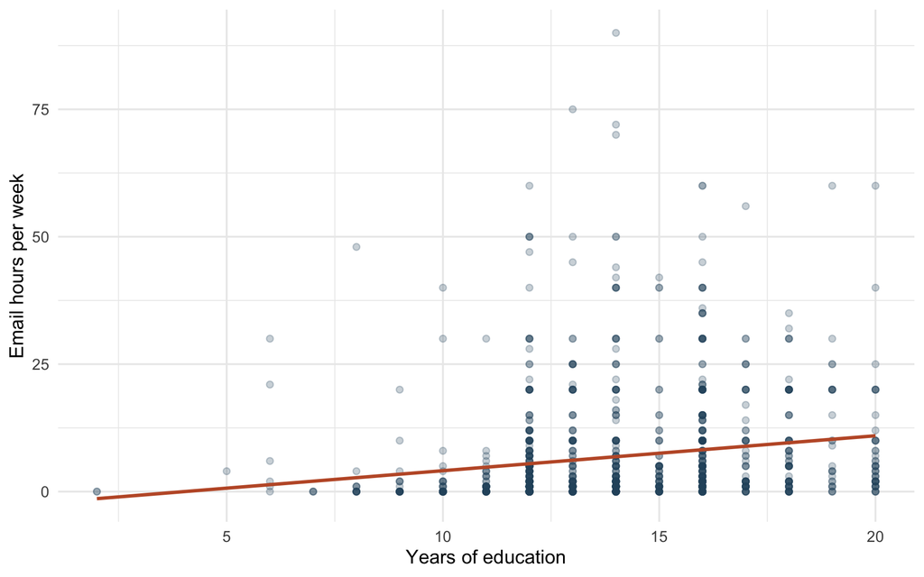

Weekly email hours versus years of education, with the fitted regression line.

```r
ggplot(gss16_advfront, aes(x = educ, y = emailhr)) +
  geom_point(alpha = 0.25, colour = "#28536B") +
  geom_smooth(method = "lm", formula = y ~ x, se = FALSE,
              colour = "#C05A32", linewidth = 1) +
  labs(x = "Years of education", y = "Email hours per week")
```

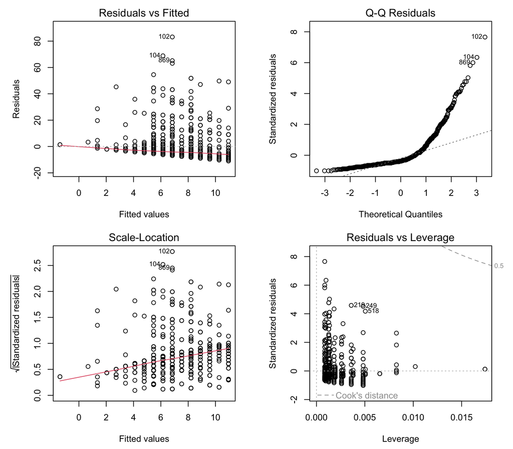

Residual diagnostics for the simple linear regression.

```r
old_par <- par(mfrow = c(2, 2), mar = c(4.5, 5, 2, 2))
plot(email_mod_1, which = c(1, 2, 3, 5))
```

```r
par(old_par)
```

The residual-versus-fitted plot shows a non-uniform vertical spread, with large positive residuals at higher fitted values. The scale-location plot also shows increasing residual spread, making constant error variance questionable. The residual smoother trends down rather than remaining horizontal around zero, which also raises doubts about the linear mean relationship. The Q-Q plot departs strongly from the reference line in the upper tail, indicating right-skewed, non-normal residuals and large outliers. The residual-versus-leverage plot helps identify observations that could influence the fitted line. The model also predicts negative hours at very low education levels.

The plots do not establish that errors are independent; this depends on the survey design, and respondents may be clustered. Overall, the low R-squared and problematic residual distribution make this model weak for individual predictions. Conventional standard errors and hypothesis tests should also be interpreted cautiously because their assumptions are questionable.

## Exercise 2: Compare two linear models

#### Exercise 2 (a)

```r
email_mod_2 <- lm(emailhr ~ educ + advfront, data = gss16_advfront)
email_coef_2 <- tidy(email_mod_2, conf.int = TRUE)
knitr::kable(email_coef_2, digits = 4,
             caption = "Multiple linear regression coefficients")
```

Multiple linear regression coefficients

| term | estimate | std.error | statistic | p.value | conf.low | conf.high |
| --- | --- | --- | --- | --- | --- | --- |
| (Intercept) | -3.0589 | 1.7576 | -1.7404 | 0.0820 | -6.5072 | 0.3894 |
| educ | 0.6775 | 0.1167 | 5.8048 | 0.0000 | 0.4485 | 0.9065 |
| advfrontAgree | 0.4809 | 0.9181 | 0.5237 | 0.6006 | -1.3205 | 2.2822 |

“Not agree” is the reference category. Holding years of education constant, respondents who agree with the statement are estimated to spend **0.481 more hours per week on email** than those who do not agree. Its 95% confidence interval is [-1.32, 2.282] hours, and p = 0.601. This interval includes zero, so the data do not provide clear evidence of an additional association after accounting for education. This is an adjusted association, not a causal effect.

#### Exercise 2 (b)

```r
email_glance_2 <- glance(email_mod_2)
linear_comparison <- bind_rows(
  "Education only" = email_glance_1,
  "Education + agreement" = email_glance_2,
  .id = "Model"
) %>%
  select(Model, nobs, r.squared, adj.r.squared, sigma, AIC, BIC)

knitr::kable(linear_comparison, digits = 4,
             caption = "Linear models fitted to the same complete observations")
```

Linear models fitted to the same complete observations

| Model | nobs | r.squared | adj.r.squared | sigma | AIC | BIC |
| --- | --- | --- | --- | --- | --- | --- |
| Education only | 1172 | 0.0291 | 0.0283 | 10.8644 | 8921.573 | 8936.772 |
| Education + agreement | 1172 | 0.0293 | 0.0277 | 10.8677 | 8923.298 | 8943.564 |

The new model explains **2.93%** of the variation, with a residual standard error of 10.87 hours. Both models therefore have poor overall explanatory performance. Adding `advfront` increases ordinary R-squared by only 0.023 percentage points. Ordinary R-squared cannot decrease when a predictor is added, so it is not sufficient evidence that the larger model is better.

**I prefer the education-only model:** it has the higher adjusted R-squared (0.0283 versus 0.0277) and the lower AIC (8921.57 versus 8923.3). These statistics account for the additional complexity. The differences are small, but the extra predictor adds little useful information. These are in-sample comparisons; they do not demonstrate better prediction on new observations.

## Exercise 3: Create a workflow to fit a model

```r
set.seed(1234)
gss16_split <- initial_split(gss16_advfront)
gss16_train <- training(gss16_split)
gss16_test  <- testing(gss16_split)
```

The specified split produces 879 training observations and 293 test observations. Both logistic models below use this same split. Their parameters and preprocessing are estimated from the training data only.

#### Exercise 3 (a)

```r
gss16_rec_1 <- recipe(advfront ~ educ, data = gss16_train)

gss16_mod_1 <- logistic_reg() %>%
  set_engine("glm") %>%
  set_mode("classification")

gss16_wflow_1 <- workflow() %>%
  add_recipe(gss16_rec_1) %>%
  add_model(gss16_mod_1)

gss16_wflow_1
```

```
#> ══ Workflow ════════════════════════════════════════════════════════════════════════════════════════
#> Preprocessor: Recipe
#> Model: logistic_reg()
#>
#> ── Preprocessor ────────────────────────────────────────────────────────────────────────────────────
#> 0 Recipe Steps
#>
#> ── Model ───────────────────────────────────────────────────────────────────────────────────────────
#> Logistic Regression Model Specification (classification)
#>
#> Computational engine: glm
```

I choose **binary logistic regression** because `advfront` has two outcome categories. It models the log-odds of agreement as a linear function of education and produces probabilities between zero and one. The `glm` engine fits a binomial model with a logit link. Education is already numeric, so no dummy encoding is needed for this first recipe.

#### Exercise 3 (b)

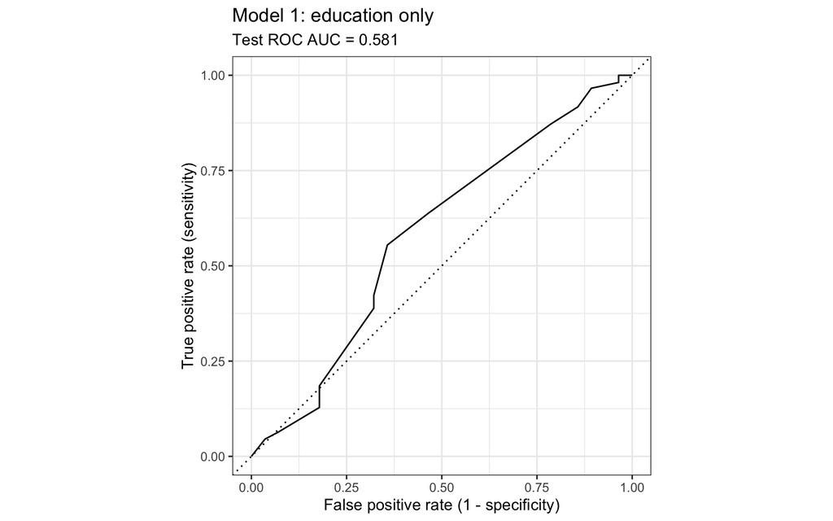

```r
gss16_fit_1 <- fit(gss16_wflow_1, data = gss16_train)

gss16_pred_1 <- bind_cols(
  gss16_test %>% select(advfront),
  predict(gss16_fit_1, new_data = gss16_test, type = "prob")
)

roc_1 <- roc_curve(gss16_pred_1, truth = advfront, .pred_Agree,
                   event_level = "second")
auc_1 <- roc_auc(gss16_pred_1, truth = advfront, .pred_Agree,
                 event_level = "second")

autoplot(roc_1) +
  labs(title = "Model 1: education only",
       subtitle = paste("Test ROC AUC =", round(auc_1$.estimate, 3)),
       x = "False positive rate (1 - specificity)",
       y = "True positive rate (sensitivity)")
```

“Agree” is the positive event throughout. Because it is the **second** factor level, `event_level = "second"` must be used with `.pred_Agree` in the ROC and performance calculations (see the [yardstick documentation](https://yardstick.tidymodels.org/reference/roc_auc.html)). The ROC curve shows sensitivity against the false positive rate across thresholds. The test AUC is **0.581**; 0.5 represents chance-level ranking and 1 represents perfect ranking.

## Exercise 4: Performance of a logistic regression

#### Exercise 4 (a)

```r
gss16_pred_1 <- gss16_pred_1 %>%
  mutate(
    .pred_class = factor(
      if_else(.pred_Agree >= 0.83, "Agree", "Not agree"),
      levels = levels(gss16_test$advfront)
    )
  )

conf_mat(gss16_pred_1, truth = advfront, estimate = .pred_class)
```

```
#>            Truth
#> Prediction  Not agree Agree
#>   Not agree        18   118
#>   Agree            10   147
```

```r
counts_083 <- gss16_pred_1 %>%
  summarise(
    TP = sum(advfront == "Agree" & .pred_class == "Agree"),
    TN = sum(advfront == "Not agree" & .pred_class == "Not agree"),
    FP = sum(advfront == "Not agree" & .pred_class == "Agree"),
    FN = sum(advfront == "Agree" & .pred_class == "Not agree")
  )

counts_083 %>%
  pivot_longer(everything(), names_to = "Outcome", values_to = "Count") %>%
  mutate(Meaning = c("True positive", "True negative",
                     "False positive", "False negative")) %>%
  select(Outcome, Meaning, Count) %>%
  knitr::kable(caption = "Test predictions at the 0.83 cutoff; positive = Agree")
```

Test predictions at the 0.83 cutoff; positive = Agree

| Outcome | Meaning | Count |
| --- | --- | --- |
| TP | True positive | 147 |
| TN | True negative | 18 |
| FP | False positive | 10 |
| FN | False negative | 118 |

```r
metrics_083 <- bind_rows(
  sens(gss16_pred_1, truth = advfront, estimate = .pred_class,
       event_level = "second"),
  spec(gss16_pred_1, truth = advfront, estimate = .pred_class,
       event_level = "second")
)
knitr::kable(metrics_083, digits = 4,
             caption = "Sensitivity and specificity at the 0.83 cutoff")
```

Sensitivity and specificity at the 0.83 cutoff

| .metric | .estimator | .estimate |
| --- | --- | --- |
| sens | binary | 0.5547 |
| spec | binary | 0.6429 |

The cutoff is applied to the **unrounded** probability of agreement, with equality included in the “Agree” prediction. The resulting rates are

$$\text{Sensitivity} = \frac{TP}{TP+FN}
= \frac{147}{147 + 118}
= 0.5547,$$

$$\text{Specificity} = \frac{TN}{TN+FP}
= \frac{18}{18 + 10}
= 0.6429.$$

The model correctly identifies 55.5% of respondents who agree and 64.3% of respondents who do not agree. Sensitivity and specificity measure performance within the actual positive and negative groups, respectively; they are not the overall accuracy.

#### Exercise 4 (b)

```r
gss16_rec_2 <- recipe(
  advfront ~ polviews + wrkstat + emailhr + educ,
  data = gss16_train
) %>%
  step_dummy(all_nominal(), -all_outcomes())

gss16_mod_2 <- logistic_reg() %>%
  set_engine("glm") %>%
  set_mode("classification")

gss16_wflow_2 <- workflow() %>%
  add_recipe(gss16_rec_2) %>%
  add_model(gss16_mod_2)

gss16_fit_2 <- fit(gss16_wflow_2, data = gss16_train)

gss16_pred_2 <- bind_cols(
  gss16_test %>% select(advfront),
  predict(gss16_fit_2, new_data = gss16_test, type = "prob")
)

roc_2 <- roc_curve(gss16_pred_2, truth = advfront, .pred_Agree,
                   event_level = "second")
auc_2 <- roc_auc(gss16_pred_2, truth = advfront, .pred_Agree,
                 event_level = "second")

auc_comparison <- bind_rows(
  "Model 1: educ" = auc_1,
  "Model 2: polviews + wrkstat + emailhr + educ" = auc_2,
  .id = "Model"
)
knitr::kable(auc_comparison, digits = 4, caption = "Test ROC AUC comparison")
```

Test ROC AUC comparison

| Model | .metric | .estimator | .estimate |
| --- | --- | --- | --- |
| Model 1: educ | roc_auc | binary | 0.5807 |
| Model 2: polviews + wrkstat + emailhr + educ | roc_auc | binary | 0.5345 |

The second model is also logistic regression because the outcome is still binary. `step_dummy(all_nominal(), -all_outcomes())` encodes the categorical predictors and explicitly excludes `advfront`. By default, it creates one fewer dummy variable than the number of levels for each predictor (see the [recipes documentation](https://recipes.tidymodels.org/reference/step_dummy.html)). The workflow learns this encoding on the training data and applies it to the test data.

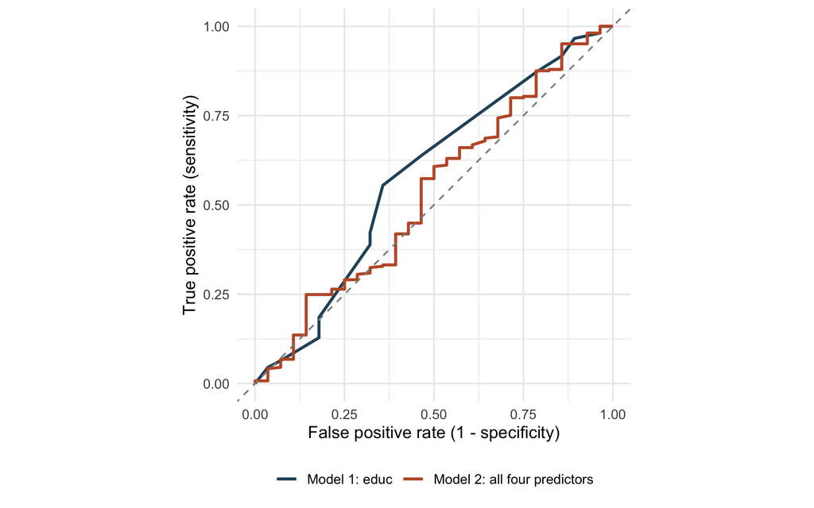

ROC curves evaluated on the same held-out test observations.

```r
bind_rows("Model 1: educ" = roc_1,
          "Model 2: all four predictors" = roc_2,
          .id = "Model") %>%
  ggplot(aes(x = 1 - specificity, y = sensitivity, colour = Model)) +
  geom_path(linewidth = 1) +
  geom_abline(intercept = 0, slope = 1, linetype = "dashed",
              colour = "grey55") +
  coord_equal() +
  scale_colour_manual(values = c("#28536B", "#C05A32")) +
  labs(x = "False positive rate (1 - specificity)",
       y = "True positive rate (sensitivity)", colour = NULL) +
  theme(legend.position = "bottom")
```

**Model 1 performs better on this test set according to ROC AUC.** Model 1 has AUC 0.5807 and Model 2 has AUC 0.5345, an absolute difference of 0.0462. Higher AUC indicates better ranking of respondents who agree above those who do not agree across thresholds; it is not the percentage correctly classified at a particular cutoff. Adding predictors does not guarantee better performance on unseen observations.

Both AUC values are close to 0.5, so neither model discriminates well between the two groups. In this split, the additional predictors do not improve out-of-sample ranking; the simpler model is preferable by the chosen metric.

This comparison uses the same held-out observations for both models, but it is based on one random split. It does not establish a statistically significant difference or guarantee the same ranking in other samples. ROC AUC also does not assess probability calibration or the practical costs of false positives and false negatives.